# Risk Factor Analysis

## Outcome Variable

**Outcome Variable:** ever_stunted

## Predictor Variables

**Intervention Variable:** hfoodsec

**Adjustment Set:**

- arm
- sex
- W_mage
- meducyrs
- feducyrs
- hhwealth_quart
- vagbrth
- W_nrooms
- W_nchldlt5
- brthmon
- W_parity
- impfloor
- impsan
- safeh20
- delta_W_mage
- delta_meducyrs
- delta_feducyrs
- delta_hhwealth_quart
- delta_vagbrth
- delta_W_nrooms
- delta_W_nchldlt5
- delta_brthmon
- delta_W_parity
- delta_impfloor
- delta_impsan
- delta_safeh20

## Stratifying Variables

The analysis was stratified on these variable(s):

- agecat
- studyid
- country

## Data Summary

| agecat | studyid | country | hfoodsec | ever_stunted | n_cell | n |
| --- | --- | --- | --- | --- | --- | --- |
| 0-6 months | ki0047075b-MAL-ED | BANGLADESH | Food Secure | 0 | 137 | 194 |
| 0-6 months | ki0047075b-MAL-ED | BANGLADESH | Food Secure | 1 | 24 | 194 |
| 0-6 months | ki0047075b-MAL-ED | BANGLADESH | Mildly Food Insecure | 0 | 3 | 194 |
| 0-6 months | ki0047075b-MAL-ED | BANGLADESH | Mildly Food Insecure | 1 | 1 | 194 |
| 0-6 months | ki0047075b-MAL-ED | BANGLADESH | Moderately Food Insecure | 0 | 20 | 194 |
| 0-6 months | ki0047075b-MAL-ED | BANGLADESH | Moderately Food Insecure | 1 | 3 | 194 |
| 0-6 months | ki0047075b-MAL-ED | BANGLADESH | Severely Food Insecure | 0 | 4 | 194 |
| 0-6 months | ki0047075b-MAL-ED | BANGLADESH | Severely Food Insecure | 1 | 2 | 194 |
| 0-6 months | ki0047075b-MAL-ED | BRAZIL | Food Secure | 0 | 3 | 129 |
| 0-6 months | ki0047075b-MAL-ED | BRAZIL | Food Secure | 1 | 0 | 129 |
| 0-6 months | ki0047075b-MAL-ED | BRAZIL | Mildly Food Insecure | 0 | 10 | 129 |
| 0-6 months | ki0047075b-MAL-ED | BRAZIL | Mildly Food Insecure | 1 | 1 | 129 |
| 0-6 months | ki0047075b-MAL-ED | BRAZIL | Moderately Food Insecure | 0 | 57 | 129 |
| 0-6 months | ki0047075b-MAL-ED | BRAZIL | Moderately Food Insecure | 1 | 10 | 129 |
| 0-6 months | ki0047075b-MAL-ED | BRAZIL | Severely Food Insecure | 0 | 46 | 129 |
| 0-6 months | ki0047075b-MAL-ED | BRAZIL | Severely Food Insecure | 1 | 2 | 129 |
| 0-6 months | ki0047075b-MAL-ED | INDIA | Food Secure | 0 | 161 | 212 |
| 0-6 months | ki0047075b-MAL-ED | INDIA | Food Secure | 1 | 29 | 212 |
| 0-6 months | ki0047075b-MAL-ED | INDIA | Mildly Food Insecure | 0 | 5 | 212 |
| 0-6 months | ki0047075b-MAL-ED | INDIA | Mildly Food Insecure | 1 | 0 | 212 |
| 0-6 months | ki0047075b-MAL-ED | INDIA | Moderately Food Insecure | 0 | 3 | 212 |
| 0-6 months | ki0047075b-MAL-ED | INDIA | Moderately Food Insecure | 1 | 1 | 212 |
| 0-6 months | ki0047075b-MAL-ED | INDIA | Severely Food Insecure | 0 | 11 | 212 |
| 0-6 months | ki0047075b-MAL-ED | INDIA | Severely Food Insecure | 1 | 2 | 212 |
| 0-6 months | ki0047075b-MAL-ED | NEPAL | Food Secure | 0 | 86 | 128 |
| 0-6 months | ki0047075b-MAL-ED | NEPAL | Food Secure | 1 | 8 | 128 |
| 0-6 months | ki0047075b-MAL-ED | NEPAL | Mildly Food Insecure | 0 | 13 | 128 |
| 0-6 months | ki0047075b-MAL-ED | NEPAL | Mildly Food Insecure | 1 | 2 | 128 |
| 0-6 months | ki0047075b-MAL-ED | NEPAL | Moderately Food Insecure | 0 | 12 | 128 |
| 0-6 months | ki0047075b-MAL-ED | NEPAL | Moderately Food Insecure | 1 | 4 | 128 |

[output cut: 222 more lines]

The following strata were considered:

- agecat: 0-24 months, studyid: ki0047075b-MAL-ED, country: BANGLADESH
- agecat: 0-24 months, studyid: ki0047075b-MAL-ED, country: BRAZIL
- agecat: 0-24 months, studyid: ki0047075b-MAL-ED, country: INDIA
- agecat: 0-24 months, studyid: ki0047075b-MAL-ED, country: NEPAL
- agecat: 0-24 months, studyid: ki0047075b-MAL-ED, country: PERU
- agecat: 0-24 months, studyid: ki0047075b-MAL-ED, country: SOUTH AFRICA
- agecat: 0-24 months, studyid: ki1017093-NIH-Birth, country: BANGLADESH
- agecat: 0-24 months, studyid: ki1017093c-NIH-Crypto, country: BANGLADESH
- agecat: 0-24 months, studyid: ki1113344-GMS-Nepal, country: NEPAL
- agecat: 0-24 months, studyid: kiGH5241-JiVitA-3, country: BANGLADESH
- agecat: 0-24 months, studyid: kiGH5241-JiVitA-4, country: BANGLADESH
- agecat: 0-6 months, studyid: ki0047075b-MAL-ED, country: BANGLADESH
- agecat: 0-6 months, studyid: ki0047075b-MAL-ED, country: BRAZIL
- agecat: 0-6 months, studyid: ki0047075b-MAL-ED, country: INDIA
- agecat: 0-6 months, studyid: ki0047075b-MAL-ED, country: NEPAL
- agecat: 0-6 months, studyid: ki0047075b-MAL-ED, country: PERU
- agecat: 0-6 months, studyid: ki0047075b-MAL-ED, country: SOUTH AFRICA
- agecat: 0-6 months, studyid: ki1017093-NIH-Birth, country: BANGLADESH
- agecat: 0-6 months, studyid: ki1017093c-NIH-Crypto, country: BANGLADESH
- agecat: 0-6 months, studyid: ki1113344-GMS-Nepal, country: NEPAL
- agecat: 0-6 months, studyid: kiGH5241-JiVitA-3, country: BANGLADESH
- agecat: 0-6 months, studyid: kiGH5241-JiVitA-4, country: BANGLADESH
- agecat: 6-24 months, studyid: ki0047075b-MAL-ED, country: BANGLADESH
- agecat: 6-24 months, studyid: ki0047075b-MAL-ED, country: BRAZIL
- agecat: 6-24 months, studyid: ki0047075b-MAL-ED, country: INDIA
- agecat: 6-24 months, studyid: ki0047075b-MAL-ED, country: NEPAL
- agecat: 6-24 months, studyid: ki0047075b-MAL-ED, country: PERU
- agecat: 6-24 months, studyid: ki0047075b-MAL-ED, country: SOUTH AFRICA
- agecat: 6-24 months, studyid: ki1017093-NIH-Birth, country: BANGLADESH
- agecat: 6-24 months, studyid: ki1017093c-NIH-Crypto, country: BANGLADESH
- agecat: 6-24 months, studyid: ki1113344-GMS-Nepal, country: NEPAL
- agecat: 6-24 months, studyid: kiGH5241-JiVitA-3, country: BANGLADESH
- agecat: 6-24 months, studyid: kiGH5241-JiVitA-4, country: BANGLADESH

### Dropped Strata

Some strata were dropped due to rare outcomes:

- agecat: 0-6 months, studyid: ki0047075b-MAL-ED, country: BANGLADESH
- agecat: 0-6 months, studyid: ki0047075b-MAL-ED, country: BRAZIL
- agecat: 0-6 months, studyid: ki0047075b-MAL-ED, country: INDIA
- agecat: 0-6 months, studyid: ki0047075b-MAL-ED, country: NEPAL
- agecat: 0-6 months, studyid: ki0047075b-MAL-ED, country: PERU
- agecat: 0-6 months, studyid: ki0047075b-MAL-ED, country: SOUTH AFRICA
- agecat: 0-6 months, studyid: ki1017093-NIH-Birth, country: BANGLADESH
- agecat: 0-6 months, studyid: ki1113344-GMS-Nepal, country: NEPAL
- agecat: 6-24 months, studyid: ki0047075b-MAL-ED, country: BANGLADESH
- agecat: 6-24 months, studyid: ki0047075b-MAL-ED, country: BRAZIL
- agecat: 6-24 months, studyid: ki0047075b-MAL-ED, country: INDIA
- agecat: 6-24 months, studyid: ki0047075b-MAL-ED, country: NEPAL
- agecat: 6-24 months, studyid: ki0047075b-MAL-ED, country: SOUTH AFRICA
- agecat: 6-24 months, studyid: ki1017093-NIH-Birth, country: BANGLADESH
- agecat: 6-24 months, studyid: ki1017093c-NIH-Crypto, country: BANGLADESH
- agecat: 0-24 months, studyid: ki0047075b-MAL-ED, country: BANGLADESH
- agecat: 0-24 months, studyid: ki0047075b-MAL-ED, country: BRAZIL
- agecat: 0-24 months, studyid: ki0047075b-MAL-ED, country: INDIA
- agecat: 0-24 months, studyid: ki0047075b-MAL-ED, country: NEPAL
- agecat: 0-24 months, studyid: ki0047075b-MAL-ED, country: SOUTH AFRICA
- agecat: 0-24 months, studyid: ki1017093-NIH-Birth, country: BANGLADESH

## Methods Detail

We’re interested in the causal parameters $E[Y_a]$ for all values of $a \in \mathcal{A}$. These parameters represent the mean outcome if, possibly contrary to fact, we intervened to set all units to have $A=a$. Under the randomization and positivity assumptions, these are identified by the statistical parameters $\psi_a=E_W[E_{Y|A,W}(Y|A=a,W)]$. In addition, we’re interested in the mean of $Y$, $E[Y]$ under no intervention (the observed mean). We will estimate these parameters by using SuperLearner to fit the relevant likelihood factors – $E_{Y|A,W}(Y|A=a,W)$ and $p(A=a|W)$, and then updating our likelihood fit using a joint TMLE.

For unadjusted analyses ($W=\{\}$), initial likelihoods were estimated using Lrnr_glm to estimate the simple $E(Y|A)$ and Lrnr_mean to estimate $p(A)$. For adjusted analyses, a small library containing Lrnr_glmnet, Lrnr_xgboost, and Lrnr_mean was used.

Having estimated these parameters, we will then use the delta method to estimate relative risks and attributable risks relative to a prespecified baseline level of $A$.

[output not shown]

[output not shown]

[output not shown]

[output not shown]

[output not shown]

[output not shown]

# Results Detail

## Results Plots

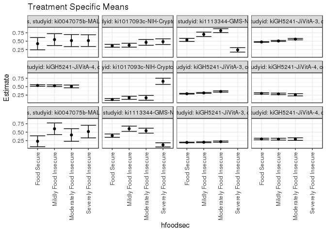

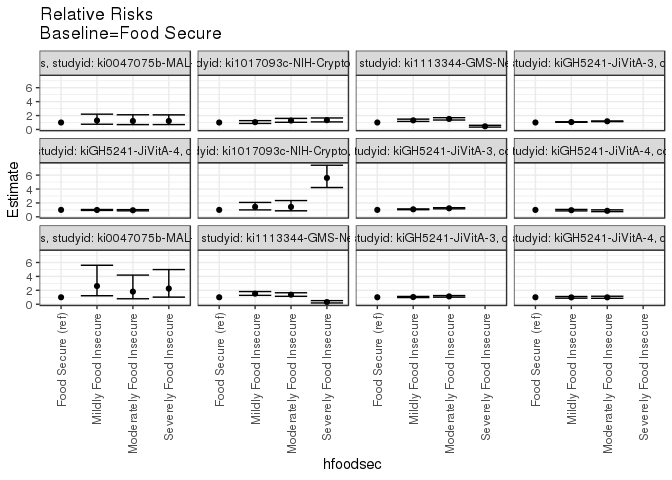

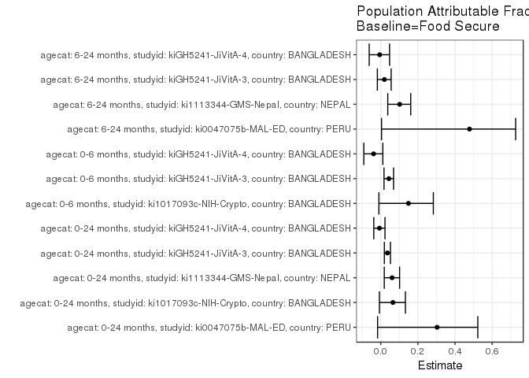

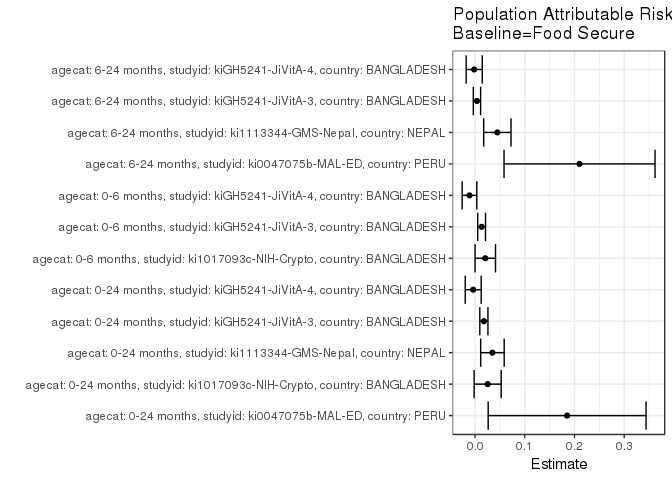

## Results Table

### Parameter: TSM

| agecat | studyid | country | intervention_level | baseline_level | estimate | ci_lower | ci_upper |
| --- | --- | --- | --- | --- | --- | --- | --- |
| 0-24 months | ki0047075b-MAL-ED | PERU | Food Secure | NA | 0.4254314 | 0.2434275 | 0.6074353 |
| 0-24 months | ki0047075b-MAL-ED | PERU | Mildly Food Insecure | NA | 0.5470121 | 0.3704586 | 0.7235656 |
| 0-24 months | ki0047075b-MAL-ED | PERU | Moderately Food Insecure | NA | 0.5168808 | 0.3384472 | 0.6953144 |
| 0-24 months | ki0047075b-MAL-ED | PERU | Severely Food Insecure | NA | 0.5167407 | 0.3418579 | 0.6916235 |
| 0-24 months | ki1017093c-NIH-Crypto | BANGLADESH | Food Secure | NA | 0.3624398 | 0.3198889 | 0.4049906 |
| 0-24 months | ki1017093c-NIH-Crypto | BANGLADESH | Mildly Food Insecure | NA | 0.3801985 | 0.3221417 | 0.4382554 |
| 0-24 months | ki1017093c-NIH-Crypto | BANGLADESH | Moderately Food Insecure | NA | 0.4637222 | 0.3780242 | 0.5494203 |
| 0-24 months | ki1017093c-NIH-Crypto | BANGLADESH | Severely Food Insecure | NA | 0.4857612 | 0.4014189 | 0.5701035 |
| 0-24 months | ki1113344-GMS-Nepal | NEPAL | Food Secure | NA | 0.5369403 | 0.4917589 | 0.5821218 |
| 0-24 months | ki1113344-GMS-Nepal | NEPAL | Mildly Food Insecure | NA | 0.7030144 | 0.6366714 | 0.7693575 |
| 0-24 months | ki1113344-GMS-Nepal | NEPAL | Moderately Food Insecure | NA | 0.8125252 | 0.7538728 | 0.8711777 |
| 0-24 months | ki1113344-GMS-Nepal | NEPAL | Severely Food Insecure | NA | 0.2415010 | 0.1747047 | 0.3082973 |
| 0-24 months | kiGH5241-JiVitA-3 | BANGLADESH | Food Secure | NA | 0.4762054 | 0.4644186 | 0.4879922 |
| 0-24 months | kiGH5241-JiVitA-3 | BANGLADESH | Mildly Food Insecure | NA | 0.5059489 | 0.4914489 | 0.5204489 |
| 0-24 months | kiGH5241-JiVitA-3 | BANGLADESH | Moderately Food Insecure | NA | 0.5594699 | 0.5395654 | 0.5793744 |
| 0-24 months | kiGH5241-JiVitA-4 | BANGLADESH | Food Secure | NA | 0.5353467 | 0.5128740 | 0.5578194 |
| 0-24 months | kiGH5241-JiVitA-4 | BANGLADESH | Mildly Food Insecure | NA | 0.5284667 | 0.5030937 | 0.5538398 |
| 0-24 months | kiGH5241-JiVitA-4 | BANGLADESH | Moderately Food Insecure | NA | 0.5064897 | 0.4658250 | 0.5471543 |
| 0-6 months | ki1017093c-NIH-Crypto | BANGLADESH | Food Secure | NA | 0.1178569 | 0.0888130 | 0.1469008 |
| 0-6 months | ki1017093c-NIH-Crypto | BANGLADESH | Mildly Food Insecure | NA | 0.1695867 | 0.1238111 | 0.2153623 |
| 0-6 months | ki1017093c-NIH-Crypto | BANGLADESH | Moderately Food Insecure | NA | 0.1681193 | 0.0958324 | 0.2404063 |
| 0-6 months | ki1017093c-NIH-Crypto | BANGLADESH | Severely Food Insecure | NA | 0.6588835 | 0.5671465 | 0.7506206 |
| 0-6 months | kiGH5241-JiVitA-3 | BANGLADESH | Food Secure | NA | 0.2901879 | 0.2795519 | 0.3008240 |
| 0-6 months | kiGH5241-JiVitA-3 | BANGLADESH | Mildly Food Insecure | NA | 0.3139195 | 0.3009828 | 0.3268562 |
| 0-6 months | kiGH5241-JiVitA-3 | BANGLADESH | Moderately Food Insecure | NA | 0.3561259 | 0.3371315 | 0.3751204 |
| 0-6 months | kiGH5241-JiVitA-4 | BANGLADESH | Food Secure | NA | 0.2986191 | 0.2779667 | 0.3192714 |
| 0-6 months | kiGH5241-JiVitA-4 | BANGLADESH | Mildly Food Insecure | NA | 0.2855526 | 0.2622540 | 0.3088513 |
| 0-6 months | kiGH5241-JiVitA-4 | BANGLADESH | Moderately Food Insecure | NA | 0.2587132 | 0.2255840 | 0.2918424 |
| 6-24 months | ki0047075b-MAL-ED | PERU | Food Secure | NA | 0.2293760 | 0.0673223 | 0.3914297 |
| 6-24 months | ki0047075b-MAL-ED | PERU | Mildly Food Insecure | NA | 0.6000548 | 0.4264996 | 0.7736101 |
| 6-24 months | ki0047075b-MAL-ED | PERU | Moderately Food Insecure | NA | 0.4159050 | 0.2283561 | 0.6034539 |
| 6-24 months | ki0047075b-MAL-ED | PERU | Severely Food Insecure | NA | 0.5170540 | 0.3296020 | 0.7045059 |
| 6-24 months | ki1113344-GMS-Nepal | NEPAL | Food Secure | NA | 0.3962188 | 0.3467057 | 0.4457318 |
| 6-24 months | ki1113344-GMS-Nepal | NEPAL | Mildly Food Insecure | NA | 0.6026251 | 0.5246573 | 0.6805930 |
| 6-24 months | ki1113344-GMS-Nepal | NEPAL | Moderately Food Insecure | NA | 0.5436392 | 0.4692762 | 0.6180023 |
| 6-24 months | ki1113344-GMS-Nepal | NEPAL | Severely Food Insecure | NA | 0.1221950 | 0.0611521 | 0.1832379 |
| 6-24 months | kiGH5241-JiVitA-3 | BANGLADESH | Food Secure | NA | 0.1936982 | 0.1833739 | 0.2040225 |
| 6-24 months | kiGH5241-JiVitA-3 | BANGLADESH | Mildly Food Insecure | NA | 0.2005471 | 0.1877043 | 0.2133899 |
| 6-24 months | kiGH5241-JiVitA-3 | BANGLADESH | Moderately Food Insecure | NA | 0.2179286 | 0.1989349 | 0.2369224 |
| 6-24 months | kiGH5241-JiVitA-4 | BANGLADESH | Food Secure | NA | 0.2966878 | 0.2733039 | 0.3200718 |
| 6-24 months | kiGH5241-JiVitA-4 | BANGLADESH | Mildly Food Insecure | NA | 0.2919382 | 0.2646382 | 0.3192381 |
| 6-24 months | kiGH5241-JiVitA-4 | BANGLADESH | Moderately Food Insecure | NA | 0.2938322 | 0.2554602 | 0.3322043 |

### Parameter: E(Y)

| agecat | studyid | country | intervention_level | baseline_level | estimate | ci_lower | ci_upper |
| --- | --- | --- | --- | --- | --- | --- | --- |
| 0-24 months | ki0047075b-MAL-ED | PERU | NA | NA | 0.6106195 | 0.5203145 | 0.7009244 |
| 0-24 months | ki1017093c-NIH-Crypto | BANGLADESH | NA | NA | 0.3878628 | 0.3531521 | 0.4225735 |
| 0-24 months | ki1113344-GMS-Nepal | NEPAL | NA | NA | 0.5719178 | 0.5317531 | 0.6120825 |
| 0-24 months | kiGH5241-JiVitA-3 | BANGLADESH | NA | NA | 0.4939877 | 0.4845041 | 0.5034712 |
| 0-24 months | kiGH5241-JiVitA-4 | BANGLADESH | NA | NA | 0.5316784 | 0.5154699 | 0.5478869 |
| 0-6 months | ki1017093c-NIH-Crypto | BANGLADESH | NA | NA | 0.1385224 | 0.1139141 | 0.1631308 |
| 0-6 months | kiGH5241-JiVitA-3 | BANGLADESH | NA | NA | 0.3034415 | 0.2954544 | 0.3114286 |
| 0-6 months | kiGH5241-JiVitA-4 | BANGLADESH | NA | NA | 0.2875098 | 0.2736314 | 0.3013882 |
| 6-24 months | ki0047075b-MAL-ED | PERU | NA | NA | 0.4395604 | 0.3370187 | 0.5421021 |
| 6-24 months | ki1113344-GMS-Nepal | NEPAL | NA | NA | 0.4411135 | 0.3960326 | 0.4861943 |
| 6-24 months | kiGH5241-JiVitA-3 | BANGLADESH | NA | NA | 0.1975885 | 0.1894938 | 0.2056833 |
| 6-24 months | kiGH5241-JiVitA-4 | BANGLADESH | NA | NA | 0.2949977 | 0.2786041 | 0.3113912 |

### Parameter: RR

| agecat | studyid | country | intervention_level | baseline_level | estimate | ci_lower | ci_upper |
| --- | --- | --- | --- | --- | --- | --- | --- |
| 0-24 months | ki0047075b-MAL-ED | PERU | Food Secure | Food Secure | 1.0000000 | 1.0000000 | 1.0000000 |
| 0-24 months | ki0047075b-MAL-ED | PERU | Mildly Food Insecure | Food Secure | 1.2857821 | 0.7526512 | 2.1965494 |
| 0-24 months | ki0047075b-MAL-ED | PERU | Moderately Food Insecure | Food Secure | 1.2149569 | 0.6993762 | 2.1106241 |
| 0-24 months | ki0047075b-MAL-ED | PERU | Severely Food Insecure | Food Secure | 1.2146276 | 0.7030362 | 2.0984982 |
| 0-24 months | ki1017093c-NIH-Crypto | BANGLADESH | Food Secure | Food Secure | 1.0000000 | 1.0000000 | 1.0000000 |
| 0-24 months | ki1017093c-NIH-Crypto | BANGLADESH | Mildly Food Insecure | Food Secure | 1.0489979 | 0.8672737 | 1.2687996 |
| 0-24 months | ki1017093c-NIH-Crypto | BANGLADESH | Moderately Food Insecure | Food Secure | 1.2794463 | 1.0298726 | 1.5895003 |
| 0-24 months | ki1017093c-NIH-Crypto | BANGLADESH | Severely Food Insecure | Food Secure | 1.3402536 | 1.0877161 | 1.6514231 |
| 0-24 months | ki1113344-GMS-Nepal | NEPAL | Food Secure | Food Secure | 1.0000000 | 1.0000000 | 1.0000000 |
| 0-24 months | ki1113344-GMS-Nepal | NEPAL | Mildly Food Insecure | Food Secure | 1.3092971 | 1.1542065 | 1.4852272 |
| 0-24 months | ki1113344-GMS-Nepal | NEPAL | Moderately Food Insecure | Food Secure | 1.5132505 | 1.3548464 | 1.6901746 |
| 0-24 months | ki1113344-GMS-Nepal | NEPAL | Severely Food Insecure | Food Secure | 0.4497725 | 0.3370269 | 0.6002349 |
| 0-24 months | kiGH5241-JiVitA-3 | BANGLADESH | Food Secure | Food Secure | 1.0000000 | 1.0000000 | 1.0000000 |
| 0-24 months | kiGH5241-JiVitA-3 | BANGLADESH | Mildly Food Insecure | Food Secure | 1.0624594 | 1.0262076 | 1.0999918 |
| 0-24 months | kiGH5241-JiVitA-3 | BANGLADESH | Moderately Food Insecure | Food Secure | 1.1748499 | 1.1282285 | 1.2233979 |
| 0-24 months | kiGH5241-JiVitA-4 | BANGLADESH | Food Secure | Food Secure | 1.0000000 | 1.0000000 | 1.0000000 |
| 0-24 months | kiGH5241-JiVitA-4 | BANGLADESH | Mildly Food Insecure | Food Secure | 0.9871485 | 0.9265734 | 1.0516838 |
| 0-24 months | kiGH5241-JiVitA-4 | BANGLADESH | Moderately Food Insecure | Food Secure | 0.9460965 | 0.8635087 | 1.0365831 |
| 0-6 months | ki1017093c-NIH-Crypto | BANGLADESH | Food Secure | Food Secure | 1.0000000 | 1.0000000 | 1.0000000 |
| 0-6 months | ki1017093c-NIH-Crypto | BANGLADESH | Mildly Food Insecure | Food Secure | 1.4389205 | 0.9983492 | 2.0739157 |
| 0-6 months | ki1017093c-NIH-Crypto | BANGLADESH | Moderately Food Insecure | Food Secure | 1.4264701 | 0.8689852 | 2.3416012 |
| 0-6 months | ki1017093c-NIH-Crypto | BANGLADESH | Severely Food Insecure | Food Secure | 5.5905385 | 4.2115003 | 7.4211370 |
| 0-6 months | kiGH5241-JiVitA-3 | BANGLADESH | Food Secure | Food Secure | 1.0000000 | 1.0000000 | 1.0000000 |
| 0-6 months | kiGH5241-JiVitA-3 | BANGLADESH | Mildly Food Insecure | Food Secure | 1.0817801 | 1.0256687 | 1.1409612 |
| 0-6 months | kiGH5241-JiVitA-3 | BANGLADESH | Moderately Food Insecure | Food Secure | 1.2272252 | 1.1512805 | 1.3081797 |
| 0-6 months | kiGH5241-JiVitA-4 | BANGLADESH | Food Secure | Food Secure | 1.0000000 | 1.0000000 | 1.0000000 |
| 0-6 months | kiGH5241-JiVitA-4 | BANGLADESH | Mildly Food Insecure | Food Secure | 0.9562437 | 0.8570004 | 1.0669798 |
| 0-6 months | kiGH5241-JiVitA-4 | BANGLADESH | Moderately Food Insecure | Food Secure | 0.8663652 | 0.7478968 | 1.0035993 |
| 6-24 months | ki0047075b-MAL-ED | PERU | Food Secure | Food Secure | 1.0000000 | 1.0000000 | 1.0000000 |
| 6-24 months | ki0047075b-MAL-ED | PERU | Mildly Food Insecure | Food Secure | 2.6160316 | 1.2222186 | 5.5993428 |
| 6-24 months | ki0047075b-MAL-ED | PERU | Moderately Food Insecure | Food Secure | 1.8132018 | 0.7858271 | 4.1837456 |
| 6-24 months | ki0047075b-MAL-ED | PERU | Severely Food Insecure | Food Secure | 2.2541765 | 1.0197693 | 4.9828049 |
| 6-24 months | ki1113344-GMS-Nepal | NEPAL | Food Secure | Food Secure | 1.0000000 | 1.0000000 | 1.0000000 |
| 6-24 months | ki1113344-GMS-Nepal | NEPAL | Mildly Food Insecure | Food Secure | 1.5209403 | 1.2712636 | 1.8196537 |
| 6-24 months | ki1113344-GMS-Nepal | NEPAL | Moderately Food Insecure | Food Secure | 1.3720683 | 1.1405308 | 1.6506099 |
| 6-24 months | ki1113344-GMS-Nepal | NEPAL | Severely Food Insecure | Food Secure | 0.3084029 | 0.1842184 | 0.5163020 |
| 6-24 months | kiGH5241-JiVitA-3 | BANGLADESH | Food Secure | Food Secure | 1.0000000 | 1.0000000 | 1.0000000 |
| 6-24 months | kiGH5241-JiVitA-3 | BANGLADESH | Mildly Food Insecure | Food Secure | 1.0353584 | 0.9565248 | 1.1206893 |
| 6-24 months | kiGH5241-JiVitA-3 | BANGLADESH | Moderately Food Insecure | Food Secure | 1.1250937 | 1.0207744 | 1.2400742 |
| 6-24 months | kiGH5241-JiVitA-4 | BANGLADESH | Food Secure | Food Secure | 1.0000000 | 1.0000000 | 1.0000000 |
| 6-24 months | kiGH5241-JiVitA-4 | BANGLADESH | Mildly Food Insecure | Food Secure | 0.9839910 | 0.8705185 | 1.1122548 |
| 6-24 months | kiGH5241-JiVitA-4 | BANGLADESH | Moderately Food Insecure | Food Secure | 0.9903751 | 0.8513292 | 1.1521312 |

### Parameter: PAR

| agecat | studyid | country | intervention_level | baseline_level | estimate | ci_lower | ci_upper |
| --- | --- | --- | --- | --- | --- | --- | --- |
| 0-24 months | ki0047075b-MAL-ED | PERU | Food Secure | NA | 0.1851881 | 0.0264306 | 0.3439456 |
| 0-24 months | ki1017093c-NIH-Crypto | BANGLADESH | Food Secure | NA | 0.0254230 | -0.0017733 | 0.0526193 |
| 0-24 months | ki1113344-GMS-Nepal | NEPAL | Food Secure | NA | 0.0349775 | 0.0113286 | 0.0586264 |
| 0-24 months | kiGH5241-JiVitA-3 | BANGLADESH | Food Secure | NA | 0.0177823 | 0.0096144 | 0.0259501 |
| 0-24 months | kiGH5241-JiVitA-4 | BANGLADESH | Food Secure | NA | -0.0036683 | -0.0197029 | 0.0123663 |
| 0-6 months | ki1017093c-NIH-Crypto | BANGLADESH | Food Secure | NA | 0.0206655 | 0.0001156 | 0.0412155 |
| 0-6 months | kiGH5241-JiVitA-3 | BANGLADESH | Food Secure | NA | 0.0132536 | 0.0054222 | 0.0210850 |
| 0-6 months | kiGH5241-JiVitA-4 | BANGLADESH | Food Secure | NA | -0.0111093 | -0.0258370 | 0.0036185 |
| 6-24 months | ki0047075b-MAL-ED | PERU | Food Secure | NA | 0.2101845 | 0.0583226 | 0.3620463 |
| 6-24 months | ki1113344-GMS-Nepal | NEPAL | Food Secure | NA | 0.0448947 | 0.0174270 | 0.0723624 |
| 6-24 months | kiGH5241-JiVitA-3 | BANGLADESH | Food Secure | NA | 0.0038903 | -0.0034583 | 0.0112389 |
| 6-24 months | kiGH5241-JiVitA-4 | BANGLADESH | Food Secure | NA | -0.0016902 | -0.0178823 | 0.0145019 |

### Parameter: PAF

| agecat | studyid | country | intervention_level | baseline_level | estimate | ci_lower | ci_upper |
| --- | --- | --- | --- | --- | --- | --- | --- |
| 0-24 months | ki0047075b-MAL-ED | PERU | Food Secure | NA | 0.3032790 | -0.0169350 | 0.5226636 |
| 0-24 months | ki1017093c-NIH-Crypto | BANGLADESH | Food Secure | NA | 0.0655464 | -0.0070856 | 0.1329402 |
| 0-24 months | ki1113344-GMS-Nepal | NEPAL | Food Secure | NA | 0.0611582 | 0.0189606 | 0.1015407 |
| 0-24 months | kiGH5241-JiVitA-3 | BANGLADESH | Food Secure | NA | 0.0359974 | 0.0193862 | 0.0523273 |
| 0-24 months | kiGH5241-JiVitA-4 | BANGLADESH | Food Secure | NA | -0.0068995 | -0.0375211 | 0.0228183 |
| 0-6 months | ki1017093c-NIH-Crypto | BANGLADESH | Food Secure | NA | 0.1491854 | -0.0099325 | 0.2832338 |
| 0-6 months | kiGH5241-JiVitA-3 | BANGLADESH | Food Secure | NA | 0.0436776 | 0.0176048 | 0.0690584 |
| 0-6 months | kiGH5241-JiVitA-4 | BANGLADESH | Food Secure | NA | -0.0386396 | -0.0911031 | 0.0113014 |
| 6-24 months | ki0047075b-MAL-ED | PERU | Food Secure | NA | 0.4781696 | 0.0042303 | 0.7265362 |
| 6-24 months | ki1113344-GMS-Nepal | NEPAL | Food Secure | NA | 0.1017759 | 0.0378779 | 0.1614302 |
| 6-24 months | kiGH5241-JiVitA-3 | BANGLADESH | Food Secure | NA | 0.0196891 | -0.0181348 | 0.0561078 |
| 6-24 months | kiGH5241-JiVitA-4 | BANGLADESH | Food Secure | NA | -0.0057294 | -0.0621347 | 0.0476805 |